# Wrangle Report - [WeRateDogs Twitter Data]

##### By: Mayowa Shobande

### Introduction

This notebook records the analysis and visualizations carried on WeRateDogs twitter data. Different plots and charts were used to create insights and visualizations.

Insights gotten from the dataset are;

1. Dog ratings frequency.
2. Five Names of dogs with the least number of retweets.
3. Five Names of dogs with the least number tweet of likes.
4. Relationship between retweets and likes of WeRateDogs tweets.
5. Top ten first dog breed prediction
6. Top ten second dog breed prediction
7. Top ten third dog breed prediction

#### Dog Ratings Frequency

Visualization was created with Bar Plot (Matplotlib) to show comparisons among dog ratings.

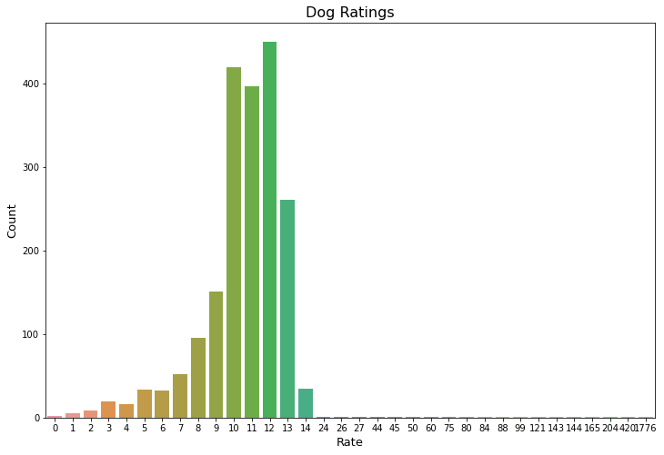

#### Five Names of Dogs With the Least Number of Retweets.

Visualization for dogs with the least number of retweets was represented with a Bar Chart.

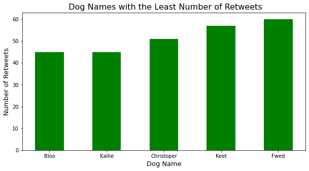

##### Observation(s)

1. WeRateDogs tweet about Bloo and Kallie had the least number of retweet (45 retweets)

#### Five Names of dogs with the least number tweet of likes.

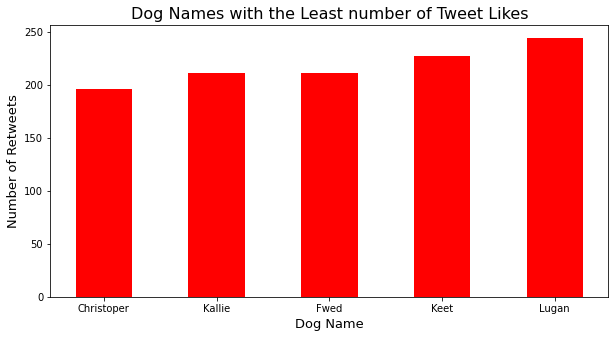

##### Observation(s)

WeRateDogs tweet about Christopher had the least number of likes (196 likes)

#### Relationship between retweets and likes of WeRateDogs tweets.

To show the relationship between number of retweets and likes, a linear regression plot was used.

Regression plot shows the relationship between a single dependent or response variable and one or more independent or predictor variables. Regression plot creates a regreesion line between 2 (two) parameters and helps to visualize their linear relationships.

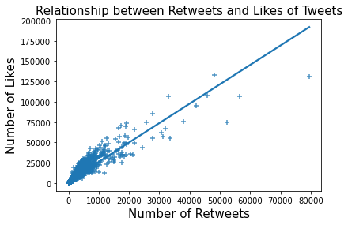

##### Observation(s)

1. There is an outlier in the plot.
2. The chart shows a positive correlation between Retweets and Likes of WeRateDogs Tweets.
3. The higher the number of retweets, the higher the number of likes.

#### Top ten first dog breed prediction

The top ten breed prediction was represented by the Horizontal Bar Plot.

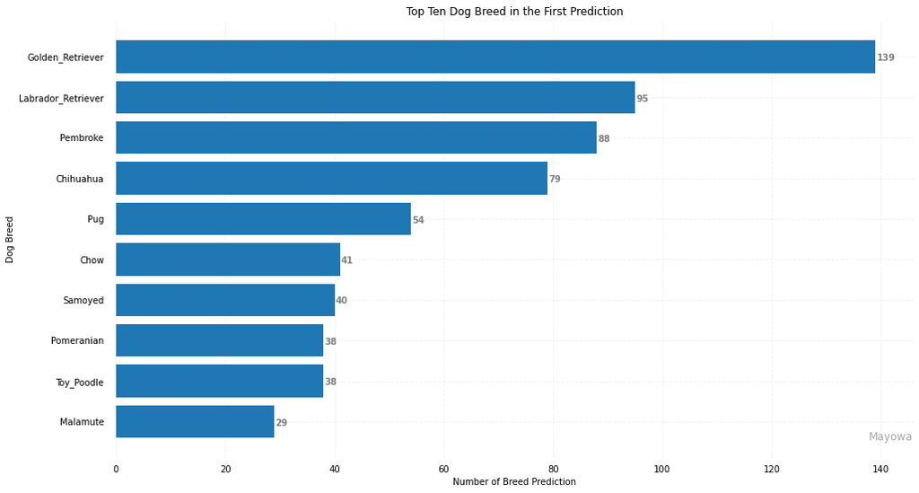

#### Top ten second dog breed prediction

A horizontal Bar Chart was used to represent the visualization of the top ten second dog prediction.

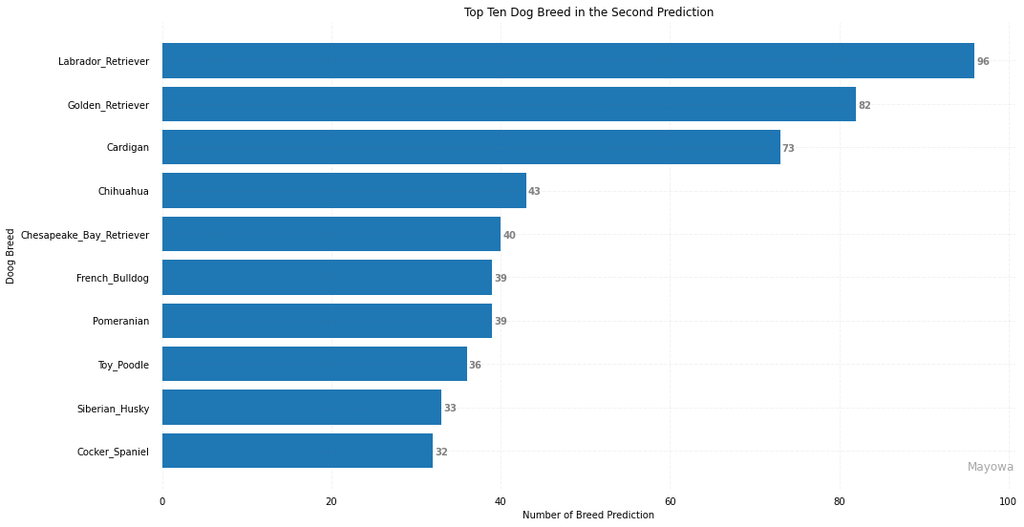

#### Top ten third dog breed prediction

A horizontal Bar Chart was used to represent the visualization of the top ten third dog prediction.

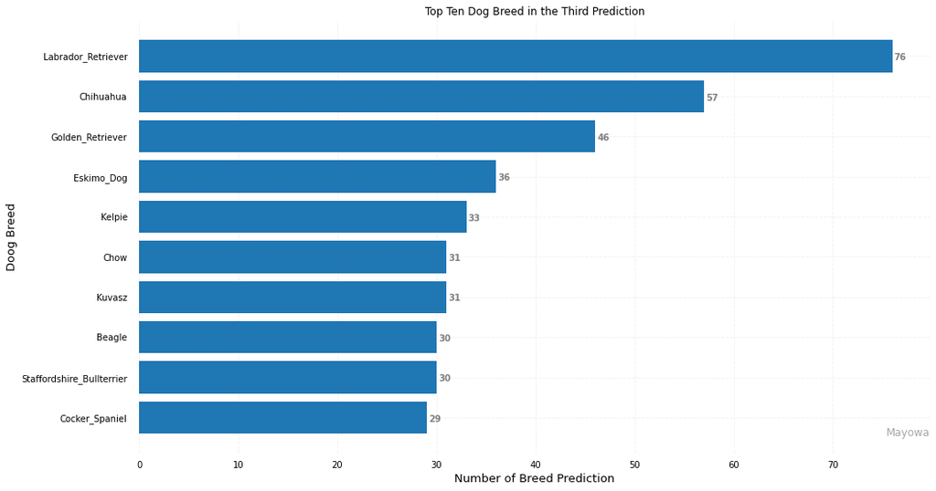

##### Observation(s)

1. The highest predicted dog breed in the third prediction was Labrador Retriever.
2. The top five predicted dog breeds was Labrador Retriever (76), Chihuahua (57), Golden Retriever (46), Eskimo Dog (36), Kelpie (33).